# Analysis of energy associated genes VS NRT2.1

Sandra

2024-10-07

## Normalisation of samples

### Normalisation by the total number of raw counts (equivalent of mapped library size)

```r
genes_energy <- read_tsv("SC18_data/genes_energy.txt")


SC18_all_WT <- read_tsv("SC18_data/SC18_Raw_HTSeq_WT.txt") %>%
  column_to_rownames(var="gene")


CPMnorm_SC18_all_WT <- cpmNormalization(SC18_all_WT)

CPM_SC18_all_WT <- as.data.frame.matrix(CPMnorm_SC18_all_WT)
```

### Z-score normalisation on top of the library size normalisation

```r
CPM_SC18_all_WT_Zscore <- mutate_all(CPM_SC18_all_WT, funs("Zscore" = (.-rowMeans(CPM_SC18_all_WT[,1:24], na.rm=TRUE))/rowSds(as.matrix(CPM_SC18_all_WT[,1:24])))) %>%
 dplyr::select( contains("Zscore")) %>%
  rename_with(~ gsub("_Zscore", "", .x, fixed = TRUE)) %>%
  rownames_to_column(var="gene")
```

## Correlation between the expression in seedlings of NRT2.1 and different genes associated with energy

Tables of correlation between each gene and NRT2.1 for genes involved in Glycolysis

```r
options(scipen=999)


CPM_SC18_all_WT_Zscore_1ColperGene_Glycolysis <- inner_join(CPM_SC18_all_WT_Zscore, genes_energy, by="gene") %>%
  filter(type%in%c("Glycolysis","NRT2.1")) %>%
  pivot_longer( cols = c(A1:A9), names_to = "seedling", values_to = "Zscore_normalised_expression") %>%
  dplyr::select(-type, - name) %>%
  pivot_wider(names_from = gene, values_from = Zscore_normalised_expression) %>%
  column_to_rownames(var="seedling")

Rcor_NRT2.1_genes_Glycolysis <- sapply(CPM_SC18_all_WT_Zscore_1ColperGene_Glycolysis, function(x) corr.test(x, CPM_SC18_all_WT_Zscore_1ColperGene_Glycolysis$AT1G08090, method="spearman")$r) %>%
  as.data.frame() %>%
  rownames_to_column(var="gene") %>%
  dplyr::rename("Rcor" =".") %>%
  inner_join(genes_energy, by="gene")


Pcor_NRT2.1_genes_Glycolysis <- sapply(CPM_SC18_all_WT_Zscore_1ColperGene_Glycolysis, function(x) corr.test(x, CPM_SC18_all_WT_Zscore_1ColperGene_Glycolysis$AT1G08090, method="spearman")$p) %>%
  as.data.frame()%>%
  rownames_to_column(var="gene") %>%
  dplyr::rename("Pcor" =".")

Corr_NRT2.1_genes_Glycolysis <- inner_join(Rcor_NRT2.1_genes_Glycolysis, Pcor_NRT2.1_genes_Glycolysis, by="gene") %>%
  filter(gene!="AT1G08090")
```

Tables of correlation between each gene and NRT2.1 for genes involved in Asp_family_pathway

```r
options(scipen=999)


CPM_SC18_all_WT_Zscore_1ColperGene_Asp_family_pathway <- inner_join(CPM_SC18_all_WT_Zscore, genes_energy, by="gene") %>%
  filter(type%in%c("Asp_family_pathway","NRT2.1")) %>%
  pivot_longer( cols = c(A1:A9), names_to = "seedling", values_to = "Zscore_normalised_expression") %>%
  dplyr::select(-type, - name) %>%
  pivot_wider(names_from = gene, values_from = Zscore_normalised_expression) %>%
  column_to_rownames(var="seedling")

Rcor_NRT2.1_genes_Asp_family_pathway <- sapply(CPM_SC18_all_WT_Zscore_1ColperGene_Asp_family_pathway, function(x) corr.test(x, CPM_SC18_all_WT_Zscore_1ColperGene_Asp_family_pathway$AT1G08090, method="spearman")$r) %>%
  as.data.frame() %>%
  rownames_to_column(var="gene") %>%
  dplyr::rename("Rcor" =".") %>%
  inner_join(genes_energy, by="gene")


Pcor_NRT2.1_genes_Asp_family_pathway <- sapply(CPM_SC18_all_WT_Zscore_1ColperGene_Asp_family_pathway, function(x) corr.test(x, CPM_SC18_all_WT_Zscore_1ColperGene_Asp_family_pathway$AT1G08090, method="spearman")$p) %>%
  as.data.frame()%>%
  rownames_to_column(var="gene") %>%
  dplyr::rename("Pcor" =".")

Corr_NRT2.1_genes_Asp_family_pathway <- inner_join(Rcor_NRT2.1_genes_Asp_family_pathway, Pcor_NRT2.1_genes_Asp_family_pathway, by="gene") %>%
  filter(gene!="AT1G08090")
```

Tables of correlation between each gene and NRT2.1 for genes involved in ATP_biosynthesis

```r
options(scipen=999)


CPM_SC18_all_WT_Zscore_1ColperGene_ATP_biosynthesis <- inner_join(CPM_SC18_all_WT_Zscore, genes_energy, by="gene") %>%
  filter(type%in%c("ATP_biosynthesis","NRT2.1")) %>%
  pivot_longer( cols = c(A1:A9), names_to = "seedling", values_to = "Zscore_normalised_expression") %>%
  dplyr::select(-type, - name) %>%
  pivot_wider(names_from = gene, values_from = Zscore_normalised_expression) %>%
  column_to_rownames(var="seedling")

Rcor_NRT2.1_genes_ATP_biosynthesis <- sapply(CPM_SC18_all_WT_Zscore_1ColperGene_ATP_biosynthesis, function(x) corr.test(x, CPM_SC18_all_WT_Zscore_1ColperGene_ATP_biosynthesis$AT1G08090, method="spearman")$r) %>%
  as.data.frame() %>%
  rownames_to_column(var="gene") %>%
  dplyr::rename("Rcor" =".") %>%
  inner_join(genes_energy, by="gene")


Pcor_NRT2.1_genes_ATP_biosynthesis <- sapply(CPM_SC18_all_WT_Zscore_1ColperGene_ATP_biosynthesis, function(x) corr.test(x, CPM_SC18_all_WT_Zscore_1ColperGene_ATP_biosynthesis$AT1G08090, method="spearman")$p) %>%
  as.data.frame()%>%
  rownames_to_column(var="gene") %>%
  dplyr::rename("Pcor" =".")

Corr_NRT2.1_genes_ATP_biosynthesis <- inner_join(Rcor_NRT2.1_genes_ATP_biosynthesis, Pcor_NRT2.1_genes_ATP_biosynthesis, by="gene") %>%
  filter(gene!="AT1G08090")
```

Tables of correlation between each gene and NRT2.1 for genes involved in Photosynthesis

```r
options(scipen=999)


CPM_SC18_all_WT_Zscore_1ColperGene_Photosynthesis <- inner_join(CPM_SC18_all_WT_Zscore, genes_energy, by="gene") %>%
  filter(type%in%c("Photosynthesis","NRT2.1")) %>%
  pivot_longer( cols = c(A1:A9), names_to = "seedling", values_to = "Zscore_normalised_expression") %>%
  dplyr::select(-type, - name) %>%
  pivot_wider(names_from = gene, values_from = Zscore_normalised_expression) %>%
  column_to_rownames(var="seedling")

Rcor_NRT2.1_genes_Photosynthesis <- sapply(CPM_SC18_all_WT_Zscore_1ColperGene_Photosynthesis, function(x) corr.test(x, CPM_SC18_all_WT_Zscore_1ColperGene_Photosynthesis$AT1G08090, method="spearman")$r) %>%
  as.data.frame() %>%
  rownames_to_column(var="gene") %>%
  dplyr::rename("Rcor" =".") %>%
  inner_join(genes_energy, by="gene")


Pcor_NRT2.1_genes_Photosynthesis <- sapply(CPM_SC18_all_WT_Zscore_1ColperGene_Photosynthesis, function(x) corr.test(x, CPM_SC18_all_WT_Zscore_1ColperGene_Photosynthesis$AT1G08090, method="spearman")$p) %>%
  as.data.frame()%>%
  rownames_to_column(var="gene") %>%
  dplyr::rename("Pcor" =".")

Corr_NRT2.1_genes_Photosynthesis <- inner_join(Rcor_NRT2.1_genes_Photosynthesis, Pcor_NRT2.1_genes_Photosynthesis, by="gene") %>%
  filter(gene!="AT1G08090")
```

Tables of correlation between each gene and NRT2.1 for genes involved in TCAcycle_mitocondrialET

```r
options(scipen=999)


CPM_SC18_all_WT_Zscore_1ColperGene_TCAcycle_mitocondrialET <- inner_join(CPM_SC18_all_WT_Zscore, genes_energy, by="gene") %>%
  filter(type%in%c("TCAcycle_mitocondrialET","NRT2.1")) %>%
  pivot_longer( cols = c(A1:A9), names_to = "seedling", values_to = "Zscore_normalised_expression") %>%
  dplyr::select(-type, - name) %>%
  pivot_wider(names_from = gene, values_from = Zscore_normalised_expression) %>%
  column_to_rownames(var="seedling")

Rcor_NRT2.1_genes_TCAcycle_mitocondrialET <- sapply(CPM_SC18_all_WT_Zscore_1ColperGene_TCAcycle_mitocondrialET, function(x) corr.test(x, CPM_SC18_all_WT_Zscore_1ColperGene_TCAcycle_mitocondrialET$AT1G08090, method="spearman")$r) %>%
  as.data.frame() %>%
  rownames_to_column(var="gene") %>%
  dplyr::rename("Rcor" =".") %>%
  inner_join(genes_energy, by="gene")


Pcor_NRT2.1_genes_TCAcycle_mitocondrialET <- sapply(CPM_SC18_all_WT_Zscore_1ColperGene_TCAcycle_mitocondrialET, function(x) corr.test(x, CPM_SC18_all_WT_Zscore_1ColperGene_TCAcycle_mitocondrialET$AT1G08090, method="spearman")$p) %>%
  as.data.frame()%>%
  rownames_to_column(var="gene") %>%
  dplyr::rename("Pcor" =".")

Corr_NRT2.1_genes_TCAcycle_mitocondrialET <- inner_join(Rcor_NRT2.1_genes_TCAcycle_mitocondrialET, Pcor_NRT2.1_genes_TCAcycle_mitocondrialET, by="gene") %>%
  filter(gene!="AT1G08090")
```

Tables of correlation between each gene and NRT2.1 for genes involved in Tetrapyrrole

```r
options(scipen=999)


CPM_SC18_all_WT_Zscore_1ColperGene_Tetrapyrrole <- inner_join(CPM_SC18_all_WT_Zscore, genes_energy, by="gene") %>%
  filter(type%in%c("Tetrapyrrole","NRT2.1")) %>%
  pivot_longer( cols = c(A1:A9), names_to = "seedling", values_to = "Zscore_normalised_expression") %>%
  dplyr::select(-type, - name) %>%
  pivot_wider(names_from = gene, values_from = Zscore_normalised_expression) %>%
  column_to_rownames(var="seedling")

Rcor_NRT2.1_genes_Tetrapyrrole <- sapply(CPM_SC18_all_WT_Zscore_1ColperGene_Tetrapyrrole, function(x) corr.test(x, CPM_SC18_all_WT_Zscore_1ColperGene_Tetrapyrrole$AT1G08090, method="spearman")$r) %>%
  as.data.frame() %>%
  rownames_to_column(var="gene") %>%
  dplyr::rename("Rcor" =".") %>%
  inner_join(genes_energy, by="gene")


Pcor_NRT2.1_genes_Tetrapyrrole <- sapply(CPM_SC18_all_WT_Zscore_1ColperGene_Tetrapyrrole, function(x) corr.test(x, CPM_SC18_all_WT_Zscore_1ColperGene_Tetrapyrrole$AT1G08090, method="spearman")$p) %>%
  as.data.frame()%>%
  rownames_to_column(var="gene") %>%
  dplyr::rename("Pcor" =".")

Corr_NRT2.1_genes_Tetrapyrrole <- inner_join(Rcor_NRT2.1_genes_Tetrapyrrole, Pcor_NRT2.1_genes_Tetrapyrrole, by="gene") %>%
  filter(gene!="AT1G08090")
```

Tables of correlation between each gene and NRT2.1 for genes involved in Nitrate nutrition

```r
options(scipen=999)

genes_Nnutrition <- read_tsv("SC18_data/Genes_interest.txt")
CPM_SC18_all_WT_Zscore_1ColperGene_Nnutrition <- inner_join(CPM_SC18_all_WT_Zscore, genes_Nnutrition, by="gene") %>%
  pivot_longer( cols = c(A1:A9), names_to = "seedling", values_to = "Zscore_normalised_expression") %>%
  dplyr::select(-type, - name) %>%
  pivot_wider(names_from = gene, values_from = Zscore_normalised_expression) %>%
  column_to_rownames(var="seedling")

Rcor_NRT2.1_genes_Nnutrition <- sapply(CPM_SC18_all_WT_Zscore_1ColperGene_Nnutrition[-1], function(x) corr.test(x, CPM_SC18_all_WT_Zscore_1ColperGene_Nnutrition$AT1G08090, method="spearman")$r) %>%
  as.data.frame() %>%
  rownames_to_column(var="gene") %>%
  dplyr::rename("Rcor" =".") %>%
  mutate(type="Nnutrition")


Pcor_NRT2.1_genes_Nnutrition <- sapply(CPM_SC18_all_WT_Zscore_1ColperGene_Nnutrition[-1], function(x) corr.test(x, CPM_SC18_all_WT_Zscore_1ColperGene_Nnutrition$AT1G08090, method="spearman")$p) %>%
  as.data.frame()%>%
  rownames_to_column(var="gene") %>%
  dplyr::rename("Pcor" =".")

Corr_NRT2.1_genes_Nnutrition <- inner_join(Rcor_NRT2.1_genes_Nnutrition, Pcor_NRT2.1_genes_Nnutrition, by="gene") %>%
  filter(gene!="AT1G08090")
```

Tables of correlation between each gene and NRT2.1 for genes involved in cell-wall

```r
options(scipen=999)

cell_wall <- read_tsv("SC18_data/genes_cell_wall_Hartasanchez.txt")
CPM_SC18_all_WT_Zscore_1ColperGene_cellWall <- inner_join(CPM_SC18_all_WT_Zscore, cell_wall, by="gene") %>%
  pivot_longer( cols = c(A1:A9), names_to = "seedling", values_to = "Zscore_normalised_expression") %>%
  dplyr::select(-type, - name) %>%
  pivot_wider(names_from = gene, values_from = Zscore_normalised_expression) %>%
  column_to_rownames(var="seedling")

Rcor_NRT2.1_genes_cellWall <- sapply(CPM_SC18_all_WT_Zscore_1ColperGene_cellWall, function(x) corr.test(x, CPM_SC18_all_WT_Zscore_1ColperGene_cellWall$AT1G08090, method="spearman")$r) %>%
  as.data.frame() %>%
  rownames_to_column(var="gene") %>%
  dplyr::rename("Rcor" =".") %>%
  inner_join(cell_wall, by="gene")
Pcor_NRT2.1_genes_cellWall <- sapply(CPM_SC18_all_WT_Zscore_1ColperGene_cellWall, function(x) corr.test(x, CPM_SC18_all_WT_Zscore_1ColperGene_cellWall$AT1G08090, method="spearman")$p) %>%
  as.data.frame()%>%
  rownames_to_column(var="gene") %>%
  dplyr::rename("Pcor" =".")
Corr_NRT2.1_genes_cellWall <- inner_join(Rcor_NRT2.1_genes_cellWall, Pcor_NRT2.1_genes_cellWall, by="gene") %>%
  filter(gene!="AT1G08090") %>%
  drop_na()
```

Plot for all groups of genes

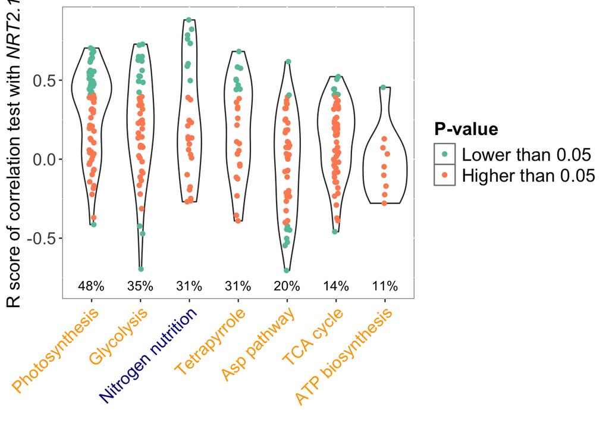

```r
Corr_NRT2.1_genes_all_groups <- bind_rows(Corr_NRT2.1_genes_Glycolysis, Corr_NRT2.1_genes_Asp_family_pathway, Corr_NRT2.1_genes_ATP_biosynthesis, Corr_NRT2.1_genes_Photosynthesis,Corr_NRT2.1_genes_TCAcycle_mitocondrialET, Corr_NRT2.1_genes_Tetrapyrrole, Corr_NRT2.1_genes_Nnutrition) %>%
  mutate(Pthreshold=ifelse(Pcor<0.05, yes="less0.05", no="more0.05"))

write_tsv(Corr_NRT2.1_genes_all_groups, file="Corr_NRT2.1_genes_all_groups.txt")


Perc_signif <- group_by(Corr_NRT2.1_genes_all_groups, type, Pthreshold) %>%
  summarise(nobs=n()) %>%
  pivot_wider(names_from = Pthreshold, values_from = nobs) %>%
  mutate(perc_signif=(less0.05/(less0.05+more0.05))*100,
         perc_signif=paste(round(perc_signif), "%", sep="")) %>%
  arrange(desc(perc_signif)) %>%
  mutate(type=factor(type, levels=c("Photosynthesis", "Glycolysis", "Nnutrition",
                                  "Tetrapyrrole", "Asp_family_pathway", "TCAcycle_mitocondrialET", "ATP_biosynthesis")))



mutate(Corr_NRT2.1_genes_all_groups, type=factor(type, levels=c("Photosynthesis", "Glycolysis", "Nnutrition",
                                  "Tetrapyrrole", "Asp_family_pathway", "TCAcycle_mitocondrialET", "ATP_biosynthesis"))) %>%
  full_join(Perc_signif, by="type") %>%
ggplot(aes(x=type, y=Rcor)) +
  geom_violin() +
  geom_jitter(aes(col=Pthreshold),height = 0, width = 0.05) +
  geom_text(data=Perc_signif, aes(y=-0.8,x=type, label=perc_signif)) +
  xlab("") +
  ylab(expression(paste("R score of correlation test with ", italic("NRT2.1")))) +
  scale_x_discrete(labels = c("Photosynthesis" = "Photosynthesis","Tetrapyrrole" = "Tetrapyrrole",
      "Glycolysis" = "Glycolysis","Nnutrition"="Nitrogen nutrition",
      "Asp_family_pathway" = "Asp pathway","TCAcycle_mitocondrialET"= "TCA cycle",
      "ATP_biosynthesis"= "ATP biosynthesis")) +
  scale_color_brewer(palette="Set2", name="P-value",labels=c("less0.05"="Lower than 0.05", "more0.05"="Higher than 0.05")) +
  theme(legend.text=element_text(size=15),legend.title = element_text(size=15, face="bold"),
        axis.text=element_text(size=14), axis.title=element_text(size=15),
        plot.title = element_text(size=16),
        panel.background = element_rect(fill = "white", colour = "grey50"),
        axis.text.x = element_text(angle = 45, hjust = 1, colour = c("orange","orange","darkblue", "orange","orange","orange","orange")))
```

```r
ggsave("Rcor_NRT2.1_genes_energie.jpg", width = 8, height = 5.5)

group_by(Corr_NRT2.1_genes_all_groups, type) %>%
  summarise(medPcor=median(Pcor)) %>%
  arrange(medPcor)
```

```
## # A tibble: 7 × 2
##   type                    medPcor
##   <chr>                     <dbl>
## 1 Photosynthesis           0.0593
## 2 Tetrapyrrole             0.122
## 3 Glycolysis               0.134
## 4 Nnutrition               0.245
## 5 Asp_family_pathway       0.265
## 6 TCAcycle_mitocondrialET  0.340
## 7 ATP_biosynthesis         0.549
```

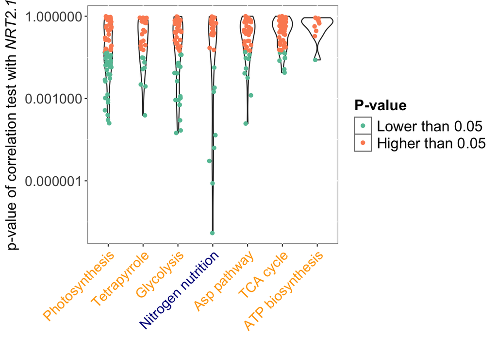

```r
mutate(Corr_NRT2.1_genes_all_groups, type=factor(type, levels=c("Photosynthesis", "Tetrapyrrole", "Glycolysis", "Nnutrition",
                                   "Asp_family_pathway", "TCAcycle_mitocondrialET", "ATP_biosynthesis"))) %>%
ggplot( aes(x=type, y=Pcor)) +
  geom_violin() +
    geom_jitter(aes(col=Pthreshold),height = 0, width = 0.1) +
  scale_y_log10()+
  xlab("") +
  ylab(expression(paste("p-value of correlation test with ", italic("NRT2.1")))) +
  scale_color_brewer(palette="Set2", name="P-value",labels=c("less0.05"="Lower than 0.05", "more0.05"="Higher than 0.05")) +
  scale_x_discrete(labels = c("Photosynthesis" = "Photosynthesis","Tetrapyrrole" = "Tetrapyrrole",
      "Glycolysis" = "Glycolysis","Nnutrition"="Nitrogen nutrition",
      "Asp_family_pathway" = "Asp pathway","TCAcycle_mitocondrialET"= "TCA cycle",
      "ATP_biosynthesis"= "ATP biosynthesis")) +
  theme(legend.text=element_text(size=15),legend.title = element_text(size=15, face="bold"),
        axis.text=element_text(size=14), axis.title=element_text(size=15),
        plot.title = element_text(size=16),
        panel.background = element_rect(fill = "white", colour = "grey50"),
        axis.text.x = element_text(angle = 45, hjust = 1, colour = c("orange","orange", "orange","darkblue","orange","orange","orange")))
```

```r
ggsave("Pcor_NRT2.1_genes_energie.jpg", width = 8, height = 5.5)


group_by(Corr_NRT2.1_genes_all_groups, type) %>%
  summarize(nobs = n(),
            n_less0.5 = sum(Pcor < 0.05),
            prop_less0.5 = n_less0.5 / nobs) %>%
  arrange(desc(prop_less0.5))
```

```
## # A tibble: 7 × 4
##   type                     nobs n_less0.5 prop_less0.5
##   <chr>                   <int>     <int>        <dbl>
## 1 Photosynthesis             67        32        0.478
## 2 Glycolysis                 48        17        0.354
## 3 Nnutrition                 26         8        0.308
## 4 Tetrapyrrole               26         8        0.308
## 5 Asp_family_pathway         44         9        0.205
## 6 TCAcycle_mitocondrialET    59         8        0.136
## 7 ATP_biosynthesis            9         1        0.111
```

## Volcano plot (correlation vs p-value) as recommender by reviewer 3

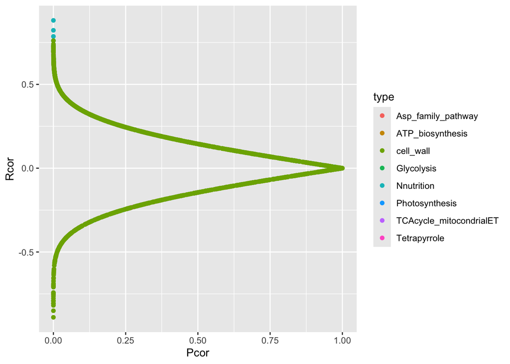

```r
Corr_NRT2.1_genes_all_groups <- bind_rows(Corr_NRT2.1_genes_Glycolysis, Corr_NRT2.1_genes_Asp_family_pathway, Corr_NRT2.1_genes_ATP_biosynthesis, Corr_NRT2.1_genes_Photosynthesis,Corr_NRT2.1_genes_TCAcycle_mitocondrialET, Corr_NRT2.1_genes_Tetrapyrrole, Corr_NRT2.1_genes_Nnutrition, Corr_NRT2.1_genes_cellWall) %>%
  mutate(Pthreshold=ifelse(Pcor<0.05, yes="less0.05", no="more0.05"))

ggplot(Corr_NRT2.1_genes_all_groups, aes(x=Pcor, y=Rcor, col=type)) +
  geom_point()
```

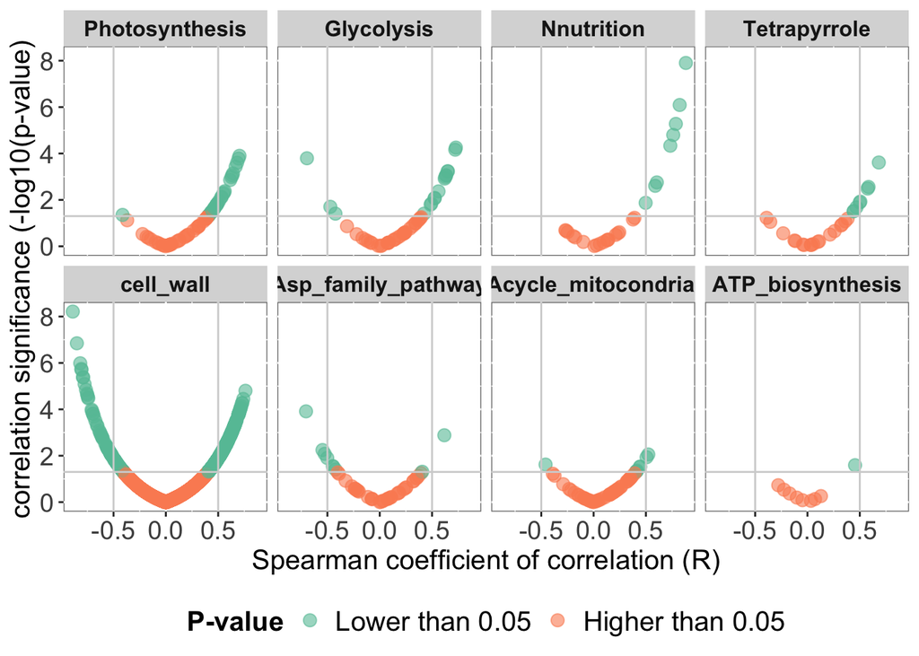

```r
mutate(Corr_NRT2.1_genes_all_groups, type=factor(type, levels=c("Photosynthesis", "Glycolysis", "Nnutrition",
                                  "Tetrapyrrole", "cell_wall", "Asp_family_pathway", "TCAcycle_mitocondrialET",
                                  "ATP_biosynthesis")),
       logCorr=-log(Pcor, 10)) %>%
ggplot( aes(x=Rcor, y=logCorr, col=Pthreshold)) +
  geom_point(size=3, alpha=0.6) +
  ylab("correlation significance (-log10(p-value)") +
  xlab("Spearman coefficient of correlation (R)") +
  geom_vline(xintercept = -0.5, col="lightgrey") +
  geom_vline(xintercept = 0.5, col="lightgrey") +
  geom_hline(yintercept = 1.30103, col="lightgrey") +
  facet_wrap(.~type, ncol = 4) +
  scale_color_brewer(palette="Set2", name="P-value",labels=c("less0.05"="Lower than 0.05", "more0.05"="Higher than 0.05"))+
   theme(legend.text=element_text(size=15),legend.title = element_text(size=15, face="bold"),
        axis.text=element_text(size=14), axis.title=element_text(size=15),
        plot.title = element_text(size=16),strip.text = element_text( face="bold", size=12),
        panel.background = element_rect(fill = "white", colour = "grey50"), legend.key = element_rect(fill = NA, color = NA), legend.position="bottom")
```

```r
ggsave(file="volcano_plot_cor_energy_genes_NRT2.2.jpg", width=12, height=9)
```